# Activity classification with the tRackIT R-Package

Jannis Gottwald

Philipps-University of Marburg, Environmental informatics

15 12, 21

## Package installation

The tRackIT R-package uses dependencies that are not published on CRAN. So before we install the package, we install these dependencies

```r
library(remotes)
Sys.setenv("R_REMOTES_NO_ERRORS_FROM_WARNINGS" = "true")
#fast rolling windows
install_github("andrewuhl/RollingWindow")
#fortran based triangulation algorithms
install_github("barryrowlingson/telemetr")
```

Now we can install the actual package from the Nature40 gitHub page.

```r
install_github(Nature40/tRackIT)
```

After the package has been installed please store the two model files from the downloaded data folder *tRackIT_activity/models* (m_r1.rds, m_r2.rds) into the extdata folder of the tRackIT-package.

## Initialize a project

For reasons of interchangeability of tRackIT projects the workflow requires the initiation of a project. A project folder (projroot) with various subfolders for products and reference data as well as a projectfile that contains a list in which all paths are stored, a data.frame with coordinates of tRackIT-stations and a data.frame with information on tagged individuals is created by the **initProject()** function. In addition, the path to absolute raw data, as created by the [software](https://github.com/Nature40/tRackIT-OS) running on the stations, which may be stored on an external hard disk and do not need to be integrated into the project, can be specified in the **initProject()** function. The epsg code of the coordinate system of the stations needs to be provided. Coordinates will be transformed to Lat/Lon.

Since data on tagged individuals and stations may be stored in tables of different style, the names of the columns containing the most important informations must be passed to the **initProject()** function. Columns that are not available need to be set to NULL. (e.g. weight_col=NULL, o_col=NULL)

```r
library(tRackIT)
#get table with station information
stations<-data.table::fread("H:/projects/repositories/active_passive/wood_pecker/data/reference_data/stations_mof_2021.csv" )
#get (create) data frame with information of tagged individuals
tags<-data.frame(ID=c("woodpecker"), species="Dendrocopos major", sex="male", age="ad", weight="20g", rep.state="breeding", start="2021-06-10", end="2021-06-14", frequency=150050, duration_min=0.012, duration_max=0.025)

#initialize tRackIT project
?initProject
proj<-initProject(projroot = "H:/projects/repositories/active_passive/wood_pecker/",logger_data_raw = "H:/projects/repositories/active_passive/wood_pecker/woodpecker_raw/", stations= stations, s_col = "station", x_col = "X", y_col = "Y", o_col = "orientation", r_col="receiver", tags=tags, id_col = "ID", spec_col = "species", sex_col = "sex", age_col = "age", weight_col = "weight", rep_col = "rep.state", start_col = "start", end_col = "end",dmax_col = "duration_max", dmin_col = "duration_min", freq_col = "frequency", epsg=4326, tz ="CET" )
```

The created folder structure looks like this

```r
folder.structure
```

```
##                     levelName
## 1  projroot
## 2   ¦--results
## 3   ¦--R
## 4   ¦   ¦--scripts
## 5   ¦   °--fun
## 6   °--data
## 7       ¦--batch_awk
## 8       ¦--calibration_curves
## 9       ¦--catalogues
## 10      ¦--correction_values
## 11      ¦--individuals
## 12      ¦--logger_data_csv
## 13      ¦--models
## 14      ¦--param_lst
## 15      °--reference_data
```

## Initializing individuals

The **initAnimal()** function creates a subdirectory in *projroot/data/individuals/* with different subdirectories for data processing products as well as an animal file containing a list of meta data information such as species, sex, age or reproductive state. Again, if any of the meta data information is not available, set it =NULL.

```r
#?initAnimal

# initialize ids

?initAnimal
anml<-initAnimal(proj, saveAnml = TRUE, animalID = proj$tags$ID[1], species = proj$tags$species[1], age = proj$tags$age[1], sex = proj$tags$sex[1], weight = proj$tags$weight[1], rep.state = proj$tags$rep.state[1], freq = proj$tags$frequency[1], start = proj$tags$start[1], end = proj$tags$end[1], duration_min = proj$tags$duration_min[1], duration_max = proj$tags$duration_max[1] )
```

Folder structure looks like this:

```r
folder.structure
```

```
##                                levelName
## 1  projroot
## 2   °--data
## 3       °--individuals
## 4           °--woodpecker
## 5               ¦--bearings
## 6               ¦--bearings_filtered
## 7               ¦--calibrated
## 8               ¦--classification
## 9               ¦--filtered
## 10              ¦--filtered_awk
## 11              ¦--gps_timematch
## 12              ¦--imputed
## 13              ¦--logger_timematch
## 14              ¦--station_timematch
## 15              ¦--triangulations
## 16              ¦--variables
## 17              °--woodpecker_idFile.rds
```

### get Project and individuals

The work steps described above only have to be carried out once. Afterwards, the project file can simply be read into the working environment with the function **getProject ()** and each individual with the function **getAnimal()**.

```r
proj<-getProject(projroot ="H:/projects/repositories/active_passive/wood_pecker/",plot = TRUE)
```

```r
anml<-getAnimal(projList = proj, animalID = "woodpecker")

print(anml$meta)
```

```
## $animalID
## [1] "woodpecker"
##
## $species
## [1] "Dendrocopos major"
##
## $sex
## [1] "male"
##
## $age
## [1] "ad"
##
## $weight
## [1] "20g"
##
## $rep.state
## [1] "breeding"
##
## $freq
## [1] "150050"
##
## $start
## [1] "2021-06-10"
##
## $end
## [1] "2021-06-14"
##
## $duration_min
## [1] "0.012"
##
## $duration_max
## [1] "0.025"
```

## raw data processing

In this step, the raw data recorded on the stations is combined into one file per station. NOTE: This part of the tutorial is only valid for data recorded with tRackIT stations. Stations of other designs may have a different data structure. On tRackIT stations, new csv files are created for the current run every time the station reboots. Over the course of one recording period, a large number of individual files can be created, which are to be combined in the next step and saved within the project structure. The **read.logger.data.tRackIT()** function does this for us. In order for it to do this, the path to the folder containing the raw data must have been specified in the **initProject()** function (argument logger_data_raw=) and the data must be present in the folder in the following structure: *logger_data_raw/name-of-station/radiotracking/files.csv*.

```r
read.logger.data.tRackIT(projList = proj)
```

This step also only needs to be carried out once per project or per data collection per project.

## Processing of individuals for activity classification

Processing of individuals involves

- Filtering
- calculation of variables for ML-classifiction
- Classification
- Aggregation

### Filtering

Individuals are filterd from the raw data compiled in the prvious step by frequency, signal length, and start and end of the tagging period using the **filter.tRackIT()** function.

```r
filter.tRackIT(projList = proj,animal = anml, freq_er = 2, path_to_data = proj$path$csv, d_min = anml$meta$duration_min, d_max = anml$meta$duration_max )
```

### calculation of variables for ML-classifiction

Here we use the **activity.vars.tRackIT()** function for ML-variable calculation. I initially divides the data set of each station into 5-minute intervals. For each interval, it selects the receiver with the most data entries out of 4 possible receivers. If available, the receiver with the second most entries is also selected. Then it calculates various predictor variables that mirror the variation of the signal strengths over time by applying rolling windows to the classified VHF-data recorded by the tRackIT- stations. In order to smooth out potentially distracting fluctuations in the signal, a hampel filter as well as a mean and a max filter is applied to the raw data of the main receiver in a rolling window of +/- 10 data entries. For the raw data as well as the smoothed data the variance, standard deviation, kurtosis, skewness and sum of squares, also in a rolling window of +/- 10 data points, are calculated.

```r
#get the animal you want to process
anml<-getAnimal(projList = proj, animalID = "woodpecker")
#calculate variables
activity.vars.tRackIT(animal = anml, tcol = "timestamp", scol = "max", dcol = "receiver", tzone = "UTC", rscale = 0)
```

### Classification

```r
activity.predict.tRackIT(animal = anml)
```

The classified files are stored in *wood_pecker/data/individuals/woodpecker/classification/*. Lets take a look:

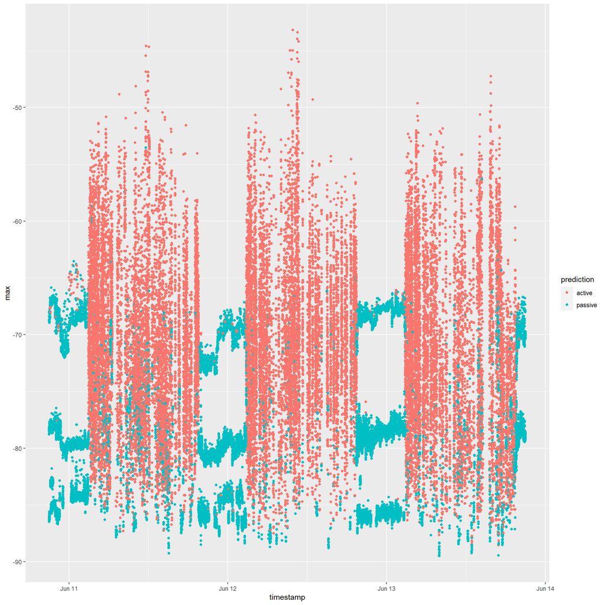

```r
library(ggplot2)
data<-data.table::fread(list.files(anml$path$classification, pattern="class",full.names = TRUE)[1])

#plot data for BirdRack obeservation period
ggplot(data[data$timestamp>="2021-06-11" & data$timestamp<="2021-06-14",], aes(x=timestamp, y=max, color=prediction))+geom_point()
```

### Aggregation

Finally, the data can be aggregated by choosing the most frequent class value in a given time interval using the function **activity.aggregate.tRackIT()**. Here we chose an inteval of 1 Minute. The aggregated data is in *projroot/data/individuals/woodpecker/classification/*.

```r
activity.aggregate.tRackIT(animal=anml, avalue = 1, tzone = "UTC")
```

### Validation

```r
library(lubridate)
library(caret)
library(ggplot2)
library(data.table)
##connection to project
proj<-getProject("H:/projects/repositories/active_passive/wood_pecker/")
##connect to individual
anml<-getAnimal(projList=proj, animalID = "woodpecker")

#get al classification data
dat<-data.table::fread(list.files(paste0(anml$path$root, "/classification/"), full.names = TRUE)[2])

#convert tmestamp format to local timezone
dat$timestamp<-lubridate::with_tz(dat$timestamp, "CET")
#get data frame with observations and corresponding videos
tag<-fread(list.files(proj$path$ref, pattern="tagging",full.names = TRUE)[1])
tag$start<-as.POSIXct(tag$start, tz="CET")
tag$end<-as.POSIXct(tag$end, tz="CET")
#select data with observations
feed<-data.frame()
for(i in 1:nrow(tag)){
  tmp<-dat[dat$timestamp>=tag$start[i] & dat$timestamp<=tag$end[i],]

  feed<-rbind(feed, tmp)

}

#activity observation: short flying sequence to tree--> very short feeding sequence (~3-5 sec)-->hopping sequence upwards tree-->short flying sequence from tree ---> all tagged as active
feed<-feed[!duplicated(feed$timestamp),]
table(feed$prediction)
```

```
##
##  active passive
##    8310     431
```

```r
feed$observed<-"active"

#passive sequences: random sample of 1000 data points between 0 and 2 am for 4 dates of observation period; 4000 data points
sleep<-data.frame()
for(d in c("2021-06-11", "2021-06-12","2021-06-13", "2021-06-14")){

  tmp<-dat[dat$timestamp>=paste0(d, " 00:00:00") & dat$timestamp<=paste0(d, " 02:00:00"),]
  tmp<-tmp[sample(nrow(tmp), 1000), ]
  sleep<-rbind(sleep, tmp)

}
table(sleep$prediction)
```

```
##
##  active passive
##      17    3983
```

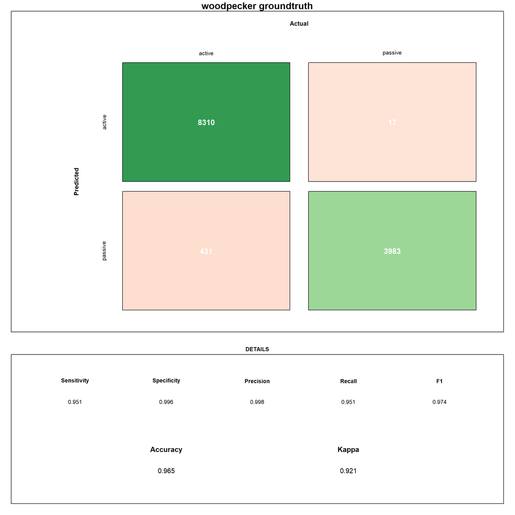

```r
sleep$observed<-"passive"

#combine to groundtruth
woodpecker_ground_truth<-rbind(feed, sleep)

#calculate confusion matrix
cmwp<-confusionMatrix(as.factor(woodpecker_ground_truth$prediction),as.factor(woodpecker_ground_truth$observed))
draw_confusion_matrix(cmwp, ttle = "woodpecker groundtruth")
```